# White Wine Quality Study

# Multivariate Analysis

### Talk about some of the relationships you observed in this part of the investigation.

I think the most surprising relationship that I observed during this investigation was between alcohol and density. This was surprising because this combination of features showed the greatest relationship to the quality. Basically, the higher the alochol content and the lower the density of the wine, the better the quality of the wine. This surprised me the most becuase it basically showed that the quality of the wine was about how drunk you would get from drinking the wine. There were no other features observed that had as clear of a relationship as these two did.

# Final Plots and Summary

### Plot One

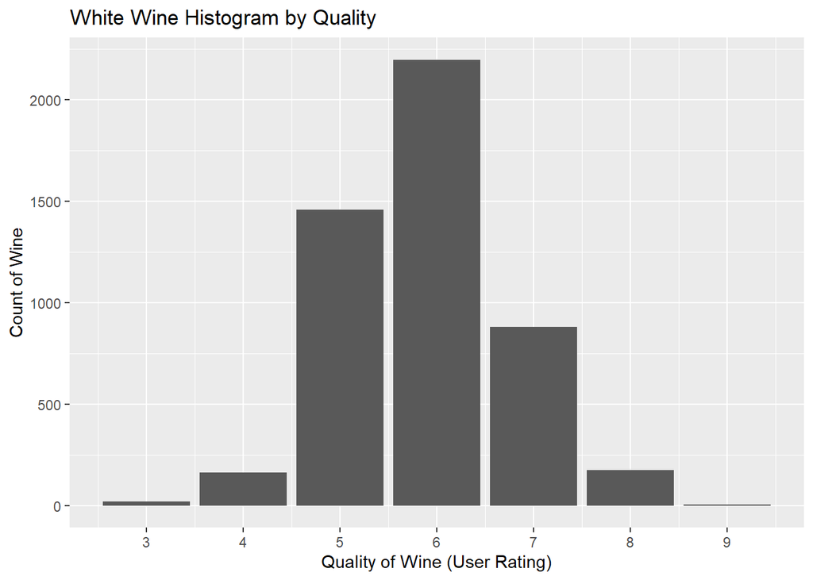

The distribution of the quality of wine is a normal distribution. This shows that the largest range of values will exist between 5-7 and will show us the most about the trends in the data.

### Plot Two

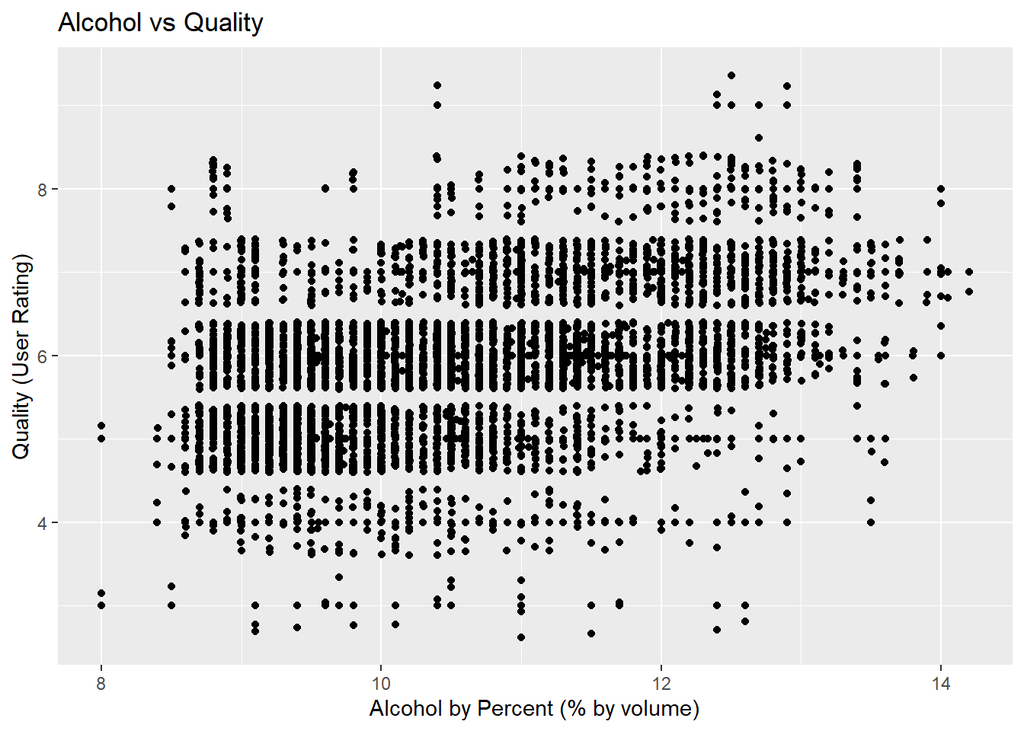

This plot shows us that as the percentage of the alcohol increases, the likelyhood the wine has a higher quality also increases.

### Plot Three

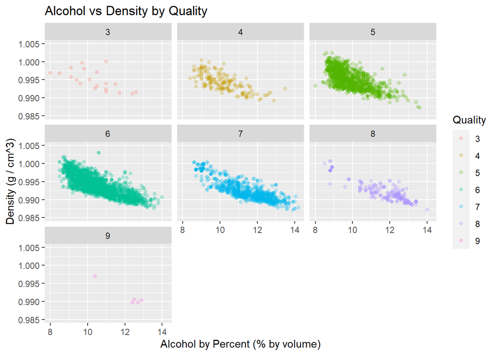

This plot shows us very clearly that using our two most important features, if we want to create a high quality wine, we should look to increase the alcoholic content of the wine, and lower the density of the wine.

# Reflection

This project taught me a lot about how to use R to analyze a dataset and discover some of the hidden secrets of the data. I really struggled on the last section, the multivariate plots. I have never had to create a multivariate plot before this project, so I didn’t have any kind of experience in what this should even look like. I had to perform some outside research on how to group the data together, and how to demonstrate the concept I wanted to highlight. I also struggled a lot with trying to create boxplots for this dataset. I include this as a struggle because I did not successfully create a boxplot of this data. Any time I tried to create a boxplot, the plot never came out looking the way that I envision it would, so this is clearly an area that I can grow in. I did experience a lot of success in the bivariate plot section. Creating these plots gave me little to no trouble, and really helped tell the story this data was trying to tell. One way I think that this analysis could be improved is to do some type of machine learning, where we train a model to look at these wines, and give us a ranking of importance somehow. We could then use that ranking to combine several of the features of the wine and see just how each feature really changes the quality of the wine.